# Data-Frame slides

## GNU R

- R 是著名的统计学语言，应用广泛
- 起源于1970年代的 S 语言
  - 在 fortran 库的基础上交互地处理数据进行统计分析
    - 调用 fortran 库提供交互环境是 S, Matlab 和 Numpy 的共同起源
  - 提供交互式的绘图工具，以便于快速迭代
  - 受 LISP 语言的影响
  - Data Frame 概念影响了几乎所有统计工具
  - S-PLUS, SAS, SPSS 应用广泛
- GNU R 重新使用 Scheme 实现了 S 语言，并以自由软件形式发布
  - 自由软件和开源运动是为科学研究提供了可 *复现* 的工具

### 为什么使用 R

- 大部分统计学算法都有 R 语言的实现
  - 非常适合快速试验，找到统计方法上的 *最佳工具*
- dplyr：数据整理的利器
  - DataFrame 上的高级关系代数运算
  - https://dplyr.tidyverse.org/
- data.table
  - 高性能的 DataFrame 实现
- 在 Jupyter 上运行 R，IRKernel
  - 与 Jupyter Python 有同样的功能，Jupyter 可以驱动各类语言
  - https://github.com/IRkernel/IRkernel
- 安装：
  - apt install r-cran-dplyr r-cran-data.table r-cran-irkernel

## R的基本数据类型

- numeric 数值型：分成整型、浮点型和复数型
- charactor 字符型
- factor 枚举型

```r
# 获得帮助
help(help)
help(numeric)
```

## 数值型

```r
10 + 66
53.2 + 5
2 * 2
```

76

58.2

4

```r
3 / 4
5 %% 2
0 / 0
```

0.75

1

NaN

```r
class(NaN)
class(3)
```

'numeric'

'numeric'

### 数组

- R 数字天然都是一个元素的数组
- 数组和数字的用法区别不大

```r
c(3,2,1) + c(4,7,8)
a <- c(3,2,1)
b <- c(4,7,8)
```

1. 7

2. 9

3. 9

```r
a * b
```

1. 12

2. 14

3. 8

```r
(3 * a + b / 2) * 1.3
```

1. 14.3

2. 12.35

3. 9.1

### 数组的索引

- 从 1 开始

```r
b[1]
b[2]
b[3]
```

4

7

8

```r
b[-1] # 除去 1
b[-3] # 除去 3
```

1. 7

2. 8

1. 4

2. 7

## 字符型

```r
"Come on, let's go!"
```

'Come on, let\'s go!'

```r
x <- "This is fine tuning"
greek <- c("alpha", "beta", "gamma", "delta")
```

```r
class(greek)
```

'character'

```r
length(x)
length(greek)
```

1

4

### 字符串操作

```r
substr(x, 5, 10)
```

' is fi'

```r
gsub('a', 'A', greek)
```

1. 'AlphA'

2. 'betA'

3. 'gAmmA'

4. 'deltA'

```r
gsub('^a', 'A', greek) # 内嵌正则表达式
gsub('a$', 'A', greek)
grep('e', greek)
```

1. 'Alpha'

2. 'beta'

3. 'gamma'

4. 'delta'

1. 'alphA'

2. 'betA'

3. 'gammA'

4. 'deltA'

1. 2

2. 4

## 布尔型

```r
class(TRUE)
```

'logical'

```r
1 == 2 / 2
TRUE | FALSE
```

TRUE

TRUE

```r
TRUE & FALSE
```

FALSE

```r
c(TRUE, FALSE, TRUE, FALSE) & c(TRUE, TRUE, FALSE, FALSE)
```

1. TRUE

2. FALSE

3. FALSE

4. FALSE

```r
greek == 'alpha'
```

1. TRUE

2. FALSE

3. FALSE

4. FALSE

## 枚举型

```r
p <- as.factor(people)
class(p)
```

'factor'

```r
levels(p)
as.numeric(p)
```

1. '女'

2. '男'

1. 2

2. 2

3. 2

4. 1

5. 1

6. 2

7. 1

8. 1

## 程序结构

- 各类语言都是相通的
- 顺序，选择，循环

### 选择结构

```r
g <- 4
if (g %% 2 == 0) {
    print("g 是偶数")
} else {
    print("g 是奇数")
}
```

```
[1] "g 是偶数"
```

### 循环结构

```r
for (i in seq(10)) {
    print(i)
}
```

```
[1] 1
[1] 2
[1] 3
[1] 4
[1] 5
[1] 6
[1] 7
[1] 8
[1] 9
[1] 10
```

```r
i <- 1
while (i <= 10) {
    print(i)
    i <- i + 1
}
```

```
[1] 1
[1] 2
[1] 3
[1] 4
[1] 5
[1] 6
[1] 7
[1] 8
[1] 9
[1] 10
```

## 函数

```r
jiggle <- function(x) {
    x + rnorm(1, sd=.1)
}
jiggle(5)
```

5.15170133326937

```r
jiggle <- function(x) {
    return(x + rnorm(1, sd=.1))
}
```

## 各类概率分布

- norm
- unif
- pois
- binom
- gamma
- exp

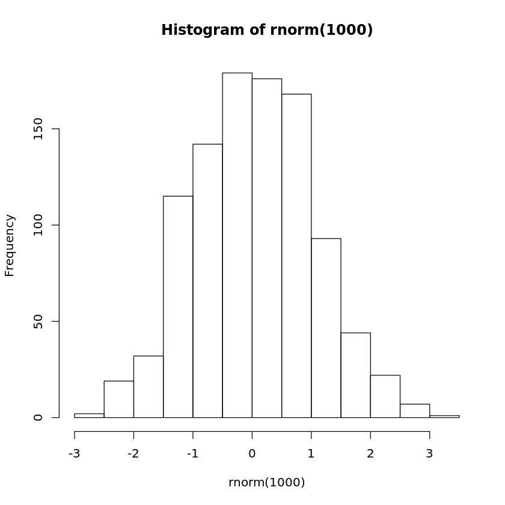

```r
hist(rnorm(1000))
```

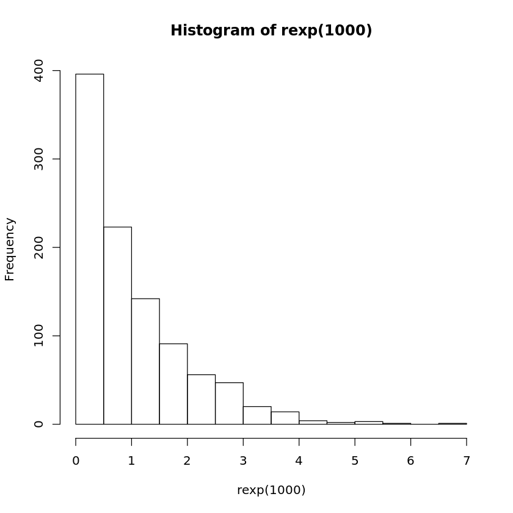

```r
hist(rexp(1000))
```

## DataFrame

- 二维表格

```r
data()
data(mtcars)
```

```r
head(mtcars)
```

|  | mpg | cyl | disp | hp | drat | wt | qsec | vs | am | gear | carb |
| --- | --- | --- | --- | --- | --- | --- | --- | --- | --- | --- | --- |
| Mazda RX4 | 21.0 | 6 | 160 | 110 | 3.90 | 2.620 | 16.46 | 0 | 1 | 4 | 4 |
| Mazda RX4 Wag | 21.0 | 6 | 160 | 110 | 3.90 | 2.875 | 17.02 | 0 | 1 | 4 | 4 |
| Datsun 710 | 22.8 | 4 | 108 | 93 | 3.85 | 2.320 | 18.61 | 1 | 1 | 4 | 1 |
| Hornet 4 Drive | 21.4 | 6 | 258 | 110 | 3.08 | 3.215 | 19.44 | 1 | 0 | 3 | 1 |
| Hornet Sportabout | 18.7 | 8 | 360 | 175 | 3.15 | 3.440 | 17.02 | 0 | 0 | 3 | 2 |
| Valiant | 18.1 | 6 | 225 | 105 | 2.76 | 3.460 | 20.22 | 1 | 0 | 3 | 1 |

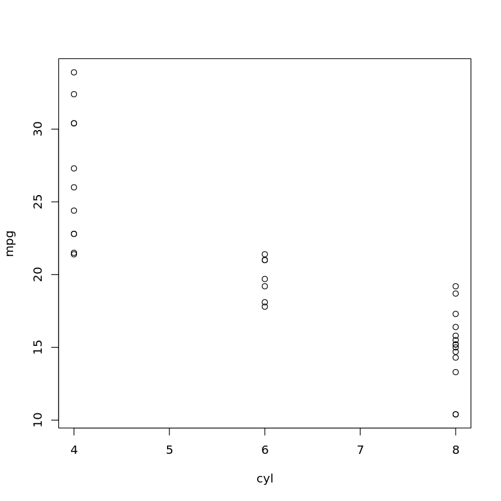

```r
plot(mpg~cyl, mtcars)
```

```r
lm(mpg~cyl, mtcars)
```

```
Call:
lm(formula = mpg ~ cyl, data = mtcars)

Coefficients:
(Intercept)          cyl
     37.885       -2.876
```

```r
mtcars$mpg
class(mtcars$mpg)
```

1. 21

2. 21

3. 22.8

4. 21.4

5. 18.7

6. 18.1

7. 14.3

8. 24.4

9. 22.8

10. 19.2

11. 17.8

12. 16.4

13. 17.3

14. 15.2

15. 10.4

16. 10.4

17. 14.7

18. 32.4

19. 30.4

20. 33.9

21. 21.5

22. 15.5

23. 15.2

24. 13.3

25. 19.2

26. 27.3

27. 26

28. 30.4

29. 15.8

30. 19.7

31. 15

32. 21.4

'numeric'

```r
sd(mtcars$mpg)
median(mtcars$mpg)
```

6.0269480520891

19.2

```r
min(mtcars$wt)
mean(mtcars$wt)
```

1.513

3.21725

```r
cars <- as.factor(rownames(mtcars))
print(cars)
```

```
 [1] Mazda RX4           Mazda RX4 Wag       Datsun 710
 [4] Hornet 4 Drive      Hornet Sportabout   Valiant
 [7] Duster 360          Merc 240D           Merc 230
[10] Merc 280            Merc 280C           Merc 450SE
[13] Merc 450SL          Merc 450SLC         Cadillac Fleetwood
[16] Lincoln Continental Chrysler Imperial   Fiat 128
[19] Honda Civic         Toyota Corolla      Toyota Corona
[22] Dodge Challenger    AMC Javelin         Camaro Z28
[25] Pontiac Firebird    Fiat X1-9           Porsche 914-2
[28] Lotus Europa        Ford Pantera L      Ferrari Dino
[31] Maserati Bora       Volvo 142E
32 Levels: AMC Javelin Cadillac Fleetwood Camaro Z28 ... Volvo 142E
```

## 熟悉 R 语言中的关系代数操作

- 集合基本运算：交、并、差，笛卡尔积

```r
A <- data.frame(ID=c(1,2), name=c("Wang", "Li"))
A
```

| ID | name |
| --- | --- |
| 1 | Wang |
| 2 | Li |

```r
B <- data.frame(ID=c(2,3), name=c("Li", "Zhang"))
B
```

| ID | name |
| --- | --- |
| 2 | Li |
| 3 | Zhang |

```r
AB <- rbind(A,B)
AB
```

| ID | name |
| --- | --- |
| 1 | Wang |
| 2 | Li |
| 2 | Li |
| 3 | Zhang |

```r
unique(AB)
```

|  | ID | name |
| --- | --- | --- |
| 1 | 1 | Wang |
| 2 | 2 | Li |
| 4 | 3 | Zhang |

```r
merge(A, B)
```

| ID | name |
| --- | --- |
| 2 | Li |

```r
require(dplyr)
setdiff(A, B)
```

| ID | name |
| --- | --- |
| 1 | Wang |

```r
AxB <- merge(A, B, by=NULL)
AxB
```

| ID.x | name.x | ID.y | name.y |
| --- | --- | --- | --- |
| 1 | Wang | 2 | Li |
| 2 | Li | 2 | Li |
| 1 | Wang | 3 | Zhang |
| 2 | Li | 3 | Zhang |

## 关系代数运算

- 投影，选择，连接，除法

```r
A$name
```

1. Wang

2. Li

1. 'Li'

2. 'Wang'

```r
subset(A, name=="Li")
```

|  | ID | name |
| --- | --- | --- |
| 2 | 2 | Li |

```r
A$GPA = c(3,4)
A
```

| ID | name | GPA |
| --- | --- | --- |
| 1 | Wang | 3 |
| 2 | Li | 4 |

```r
B$age = c(19, 20)
B
```

| ID | name | age |
| --- | --- | --- |
| 2 | Li | 19 |
| 3 | Zhang | 20 |

```r
# 内连接
merge(A, B)
```

| ID | name | GPA | age |
| --- | --- | --- | --- |
| 2 | Li | 4 | 19 |

```r
# 左连接
merge(A, B, all.x=TRUE)
```

| ID | name | GPA | age |
| --- | --- | --- | --- |
| 1 | Wang | 3 | NA |
| 2 | Li | 4 | 19 |

```r
# 右连接
merge(A, B, all.y=TRUE)
```

| ID | name | GPA | age |
| --- | --- | --- | --- |
| 2 | Li | 4 | 19 |
| 3 | Zhang | NA | 20 |

```r
# 外连接
merge(A, B, all=TRUE)
```

| ID | name | GPA | age |
| --- | --- | --- | --- |
| 1 | Wang | 3 | NA |
| 2 | Li | 4 | 19 |
| 3 | Zhang | NA | 20 |

## 关系代数之外的常用运算

- GroupBy, SortBy

```r
AxB
```

| ID.x | name.x | ID.y | name.y |
| --- | --- | --- | --- |
| 1 | Wang | 2 | Li |
| 2 | Li | 2 | Li |
| 1 | Wang | 3 | Zhang |
| 2 | Li | 3 | Zhang |

```r
AxB %>% group_by(name.x) %>% summarise(n=n())
```

| name.x | n |
| --- | --- |
| Li | 2 |
| Wang | 2 |

```r
order(AxB$name.x)
```

1. 2

2. 4

3. 1

4. 3

```r
AxB[order(AxB$name.x),]
```

|  | ID.x | name.x | ID.y | name.y |
| --- | --- | --- | --- | --- |
| 2 | 2 | Li | 2 | Li |
| 4 | 2 | Li | 3 | Zhang |
| 1 | 1 | Wang | 2 | Li |
| 3 | 1 | Wang | 3 | Zhang |